# DES_part2_03679401

- Programming Assignment - Part 2 : "Extending the DES"
- 2.6 Verification:

```python
import part2_tests
%run part2_tests
```

```
......
----------------------------------------------------------------------
Ran 6 tests in 0.090s

OK
```

- 2.7 Simulation Study II :

```python
import part2_simstudy
%matplotlib inline
import matplotlib
import numpy as np
import matplotlib.pyplot as plt
import pylab
```

- Task 2.7.1: Systems with Different Queue Capacity I :

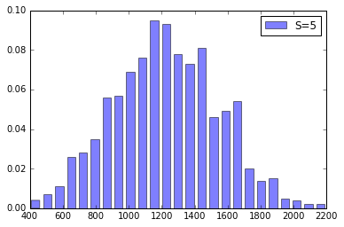

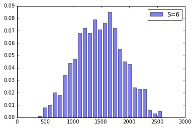

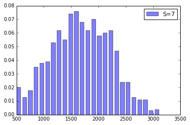

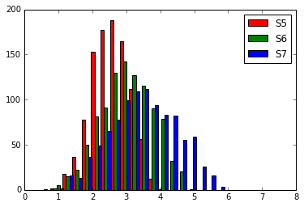

```python
part2_simstudy.task_2_7_1()
```

We have three histograms for the mean waiting time and one plot for the mean queue size using the side-by-side plot for the different queue capacities.

- Task 2.7.2: Systems with Different Queue Capacity II :

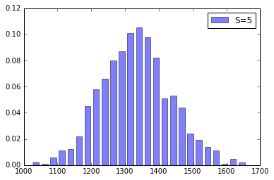

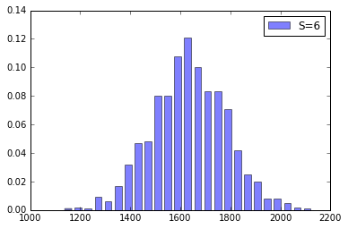

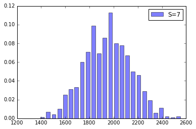

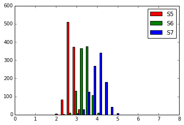

```python
part2_simstudy.task_2_7_2()
```

We have three histograms for the mean waiting time and one plot for the mean queue size using the side-by-side plot for the different queue capacities.

- 2.8 Analysis and General Questions :
- Task 2.8.1: Systems with Different Queue Capacity :

We observe from the plots that the mean waiting time distribution and the the mean queue length (buffer fill status) distribution are "Normal" distributions and that is predictable since the mean waiting time and the mean queue length are both a process that is the sum of a number of component processes (central limit theorem (CLT)).

We note from the plots that the mean of the mean waiting time distribution and also the mean of the mean queue length (buffer fill status) distribution is increasing when the queue size increases. We observe also that the variance of the distributions is increasing when the queue size increases.

- Task 2.8.2: Choosing the right number of bins :

I modify the number of bins in order to find the plot that represents more our predictable distribution (normal distribution in our case).

- Task 2.8.3*: Variance Calculation :

This is the problem of "Correction for variance". In fact, we correct the estimation of the variance with divising by (n-1) in stead of divising by (n) and with the use of an estimated mean.